# Introduction to Sampling and Hypothesis Testing

## Central Limit Theorem - demo

```python
import numpy as np
import matplotlib.pyplot as plt
from scipy import stats
```

### *X* = the number of sixes obtained when rolling ten dice

The probability distribution for our variable $X$ is binomial:

```python
sixes = stats.binom(10, 1/6)  # n=10, p=1/6
```

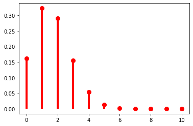

```python
# plot the probability mass function
x = np.arange(11)
plt.plot(x,sixes.pmf(x), 'ro', ms=8)
plt.vlines(x, 0, sixes.pmf(x), colors='r', lw=4)
plt.show()
```

The population mean, $\mu$:

```python
sixes.mean()
```

```
1.6666666666666665
```

The population variance, $\sigma^2$:

```python
sixes.var()
```

```
1.3888888888888888
```

Let's imagine taking a sample of size $n$ (i.e. $n$ observations of the variable $X$):

```python
n = 50
sample = sixes.rvs(size=n)
print(sample)
```

```
[4 4 2 2 1 2 2 1 2 1 2 3 2 0 0 2 0 3 0 2 1 0 2 1 1 2 5 3 2 2 0 1 2 1 2 1 2
 2 1 2 3 1 2 3 3 1 4 0 2 0]
```

We can plot the observed distribution of our sampled data, $x$.

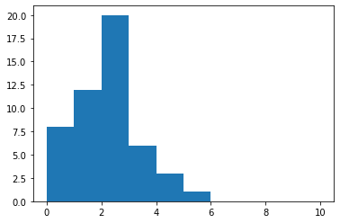

```python
x = np.arange(11)
plt.hist(sample, bins=x)
plt.show()
```

For this particular sample, the sample mean, $\bar{x}$ is

```python
sample.mean()
```

```
1.74
```

and the sample variance, $s^2$, is

```python
sample.var()
```

```
1.3524
```

Notice that the value of $\bar{x}$ changes depending on the sample. We can treat it as an observation from a new random variable, $\bar{X}$.

Now if we repeat this process many times and plot a histogram of these sample means (the observed distribution of $\bar{X}$)...

```python
xbars = []
for i in range(1000):
    sample = sixes.rvs(size=n)
    xbar = np.mean(sample)
    xbars.append(xbar)
```

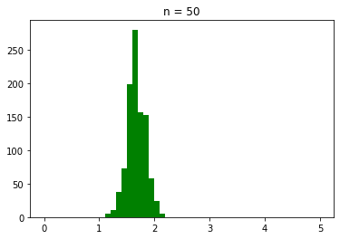

```python
fig, ax = plt.subplots(1, 1)
ax.hist(xbars,bins=50,range=(0,5), color='g')
ax.set_title("n = " + str(n))
plt.show()
```

The width of this histogram depends strongly on the sample size, $n$.

You can see that the distribution of $\bar{X}$ is very different to the distribution of $X$, although it is centred around the same mean value. We call this the **sampling distribution of the mean**.

For a sample of size $n$, the **central limit theorem** states that $\bar{X}$ converges to a *normal distribution* as $n$ becomes large:

$$ N \approx N(\mu, \frac{\sigma^2}{n}) $$

The standard deviation of the $\bar{X}$ distribution is called the **standard error**, $\frac{\sigma}{\sqrt{n}}$.

When $n$ is large, we can estimate the standard error as $\frac{s}{\sqrt{n}}$.